# Assignment

The assignment will require you to complete cells, create new ones, and move around some cells. You need to familiarize yourself with the Jupyter notebook interface. You can find a tutorial [here](https://www.dataquest.io/blog/jupyter-notebook-tutorial/).

**MAKE SURE TO MAKE A COPY OF THIS ASSIGNMENT IN YOUR OWN REPOSITORY.** (delete this line in your new copy :) )

# [EXERCISE 1]

## Agostina Fares

### afares@mail.austral.edu.ar

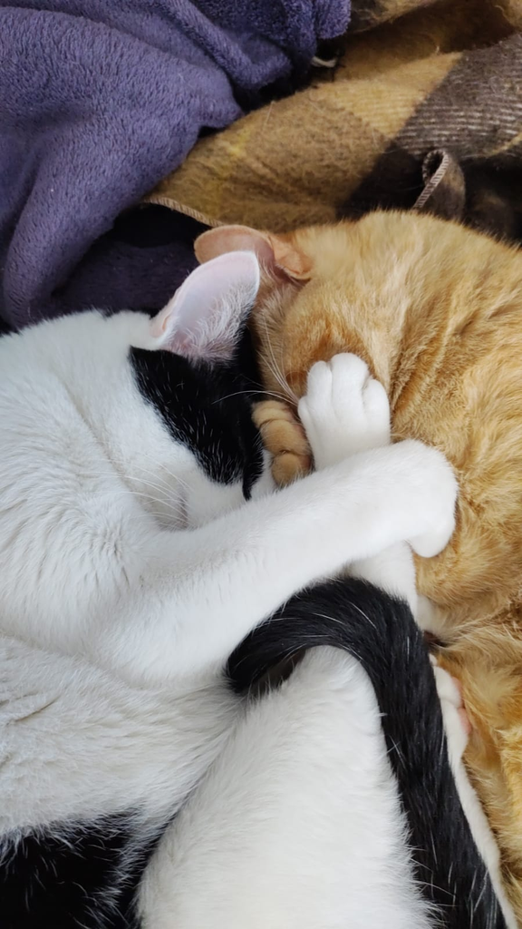

# [EXERCISE 2]

```python
#CREATE A NEW CELL BELOW THIS ONE AND ADD A MARKDOWN TITLE (HEADING 1) WITH THE TEXT "[EXERCISE 2]"
#Create a new cell below the one with a markdown title of "[EXERCISE 2]" to solve the following exercise in python, it needs to be a CODE cell:
#Write a function rectangle_area(width, height) that takes the width and height of a rectangle as input and returns its area.
#Add the instructions of the exercise as a comment in the code cell above the function definition.

def rectangle_area(width, height):
    area = width * height
    print (f"The area of a rectangle with width {width} and height {height} is {area}")
```

# [EXERCISE 3]

```python
#CREATE A NEW CELL BELOW THIS ONE AND ADD A MARKDOWN TITLE (HEADING 1) WITH THE TEXT "[EXERCISE 3]"
#Use your created function to calculate the area of a rectangle with width 3 and height 4. Another of width 5 and height 10, and another of width 8 and height 2. Show your results in the same cell with a description of each result. Similar to this example:
# `The area of a rectangle with width 3 and height 4 is 12.`
#Add the instructions of the exercise as a comment in the code cell with the solution.

rectangle_area(3,4)
rectangle_area(5,10)
rectangle_area(8,2)
```

```
The area of a rectangle with width 3 and height 4 is 12
The area of a rectangle with width 5 and height 10 is 50
The area of a rectangle with width 8 and height 2 is 16
```

# [EXERCISE 5]

1. CREATE A NEW CELL BELOW THIS ONE AND ADD A MARKDOWN TITLE (HEADING 1) WITH THE TEXT "[EXERCISE 5]"
2. CREATE A NEW CELL BELOW THE ONE WITH THE MARKDOWN TITLE OF "[EXERCISE 5]" TO SOLVE THE FOLLOWING EXERCISE IN PYTHON:

   `Write a function central_difference(f, x, h) that approximates the derivative of a function f at a point x using the Central Difference Approximation. The function should take the function f, the point at which the derivative needs to be approximated x, and the step size h as input, and return the approximate value of the derivative.`

https://en.wikipedia.org/wiki/Finite_difference

4. DO NOT KEEP THE CELL WITH THESE INSTRUCTIONS.

# [EXERCISE 5]

```python
def function(x):
    return x**2

def central_difference(f, x, h):
    x2 = x+h
    x3 = x-h
    derivada = (f(x2)-f(x3))/(2*h)
    return derivada
```

```python
print (f"The derivative of f(x) = x^2 at x = 2 using h = 0.1 is {central_difference(function, 2, 0.1)}")
print (f"The derivative of f(x) = x^2 at x = 2 using h = 0.01 is {central_difference(function, 2, 0.01)}")
print (f"The derivative of f(x) = x^2 at x = 2 using h = 0.001 is {central_difference(function, 2, 0.001)}")
```

```
The derivative of f(x) = x^2 at x = 2 using h = 0.1 is 4.000000000000001
The derivative of f(x) = x^2 at x = 2 using h = 0.01 is 3.999999999999937
The derivative of f(x) = x^2 at x = 2 using h = 0.001 is 3.9999999999995595
```